# Homework4

Matheus Vanzela

22/08/2023

## Usei pacotes diferentes apenas para testar as funcionalidades

```r
# Bibliotecas
library(tseries)
library(fGarch)
library(forecast)
# Function to calculate persistency
persist <- function(modelo.garch){
  persistence <- modelo.garch@fit[["coef"]][["beta1"]]+modelo.garch@fit[["coef"]][["alpha1"]]+modelo.garch@fit[["coef"]][["omega"]]
  return(persistence)
}

# Function to calculate half life
hl <- function(persistencia){
  L <- log(0.5)/log(persistencia)
  return(L)
}
```

```r
# Downloading PETR4 data from Yahoo Finance
petr4 <- get.hist.quote(instrument = "PETR4.SA", start = "2019-01-01", end = Sys.Date(), quote = "Close")
```

```
## time series starts 2019-01-02
## time series ends   2023-08-21
```

```r
ibov <- get.hist.quote(instrument = "^BVSP", start = "2019-01-01", end = Sys.Date(), quote = "Close")
```

```
## time series starts 2019-01-02
## time series ends   2023-08-21
```

```r
# Eliminating NA's
petr4 = petr4[is.na(petr4)==F]
ibov = ibov[is.na(ibov)==F]

# Calculating returns
petr4_returns <- diff(log(petr4))
ibov_returns <- diff(log(ibov))
```

# Exercício 1

##a) alpha é o parâmetro do modelo ARCH(1) que mede o impacto do erro do período anterior na variância condicional atual. Omega pode ser entendido como o valor da variação caso as variações ao longo do tempo não estivessem sendo passadas para a eq do ARCH(1). Ambos devem ser não-negativos para garantir que a variância condicional seja sempre positiva, condição de existência da variância no R.

##b) Eles permitem avaliar clusters de volatilidade, ou seja, períodos de alta ou baixa volatilidade, modelando a variância condicional dos retornos como uma função de seus valores passados. Isso permite que os modelos ARCH capturem a persistência da volatilidade e identifiquem clusters de volatilidade nos dados.

##d) O modelo ARCH(1) é um caso específico em que a variância condicional é modelada como uma função linear do quadrado do erro do período anterior; variância incondicional é a variância calculado para todos os períodos.

# Exercício 2

No contexto dos modelos ARCH, as funções de autocorrelação e autocorrelação parciais podem ser usadas para identificar e validar a forma dos modelos GARCH. Além disso a FAC dos resíduos ao quadrado mostram ou não autocorrelação parcial dos residuos. Em modelos aderentes à família ARCH os resíduos ao quadrado tem FAC com decaimento lento.

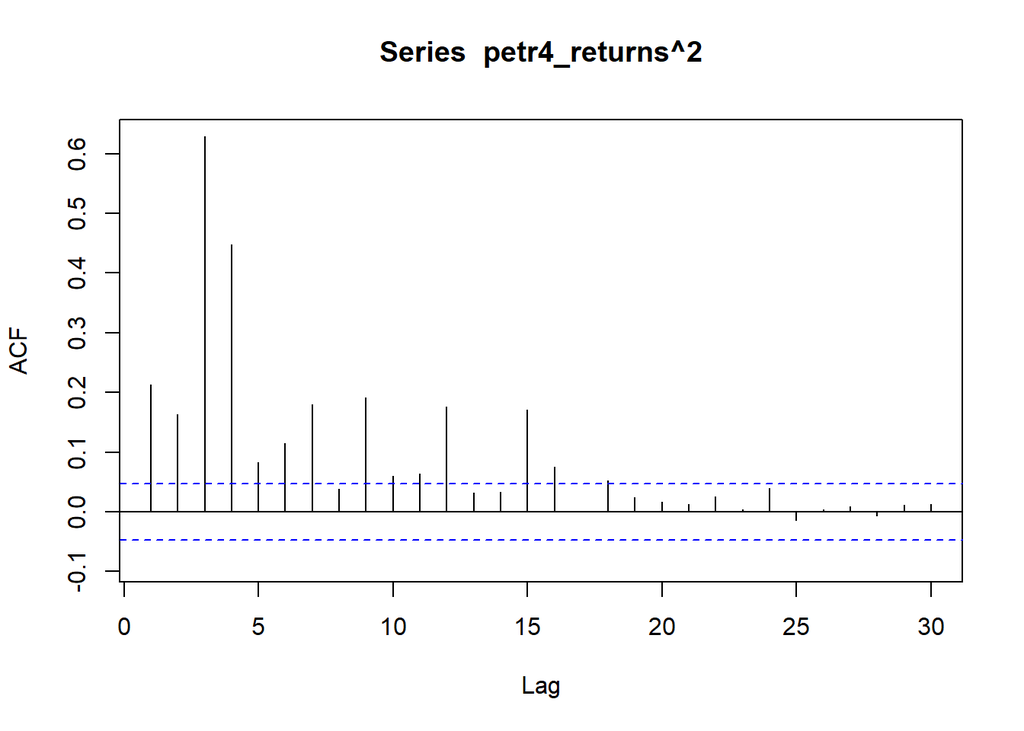

```r
# Plots do quadrado dos resíduos
Acf(petr4_returns^2, na.action = na.pass)
```

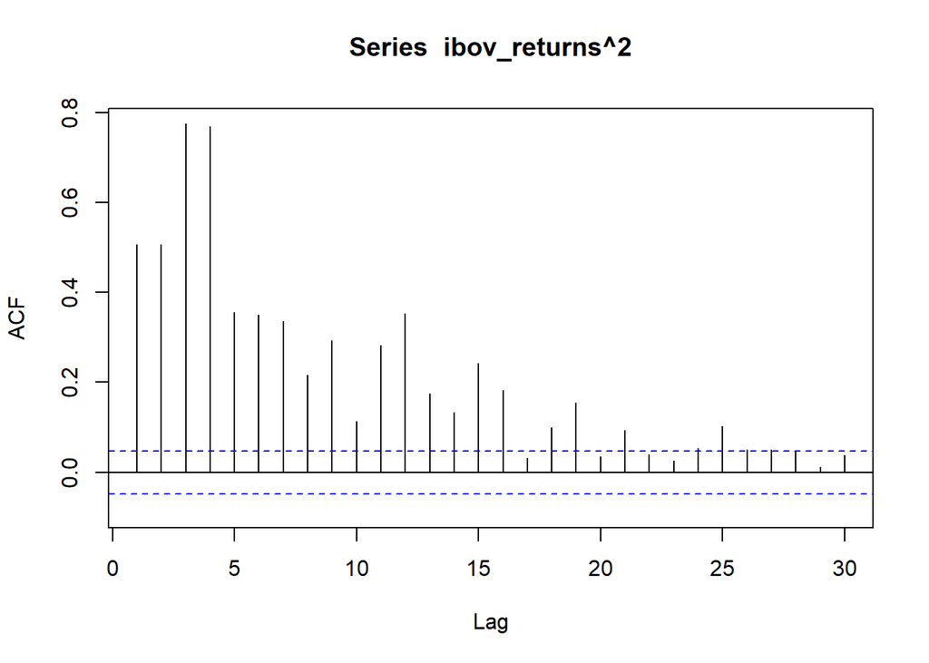

```r
Acf(ibov_returns^2, na.action = na.pass)
```

Nota-se o decaimento lento no gráfico de autocorrelação do quadrado dos residuos, indicando modelagem da volatilidade pelos modelos ARCH.

## Exercício 3

Código para gerar os modelos de acordo com o que foi exigido na questão.

```r
garch.petr.t = garchFit(formula = ~garch(1,1), data = petr4_returns, cond.dist = "std", trace = FALSE)
garch.ibov.t = garchFit(formula = ~garch(1,1), data = ibov_returns, cond.dist = "std", trace = FALSE)
garch.ibov.norm = garchFit(formula = ~garch(1,1), data = ibov_returns, cond.dist = "norm", trace = FALSE)
garch.petr.norm = garchFit(formula = ~garch(1,1), data = petr4_returns, cond.dist = "norm", trace = FALSE)
```

## Exercício 4

```r
#
# IBOV
p.ibov.t <- persist(garch.ibov.t)
p.ibov.t
```

```
## [1] 0.9527003
```

```r
p.ibov.n <- persist(garch.ibov.norm)
p.ibov.n
```

```
## [1] 0.9496475
```

```r
hl(p.ibov.t)
```

```
## [1] 14.30498
```

```r
hl(p.ibov.n)
```

```
## [1] 13.41633
```

```r
#PETROBRAS
p.petr.t <- persist(garch.petr.t)
p.petr.t
```

```
## [1] 0.9413489
```

```r
p.petr.n <- persist(garch.petr.norm)
p.petr.n
```

```
## [1] 0.8687457
```

```r
hl(p.petr.t)
```

```
## [1] 11.46807
```

```r
hl(p.petr.n)
```

```
## [1] 4.92625
```

A persistencia e a half life relacionada a distribuição t-Student é maior, indicando que os choques tem maior representação quando modelados pela distribuição t-Student.

No caso da PETR4 a diferença mostrou-se ainda maior. É importante destacar que nos dois testes, tanto para o IBOV quanto para PETR a persistencia tem um valor próximo de 1, indicando uma alta persistência dos choques.

Ainda é importante observar que a diferença entre os valores de Half Life no caso de PETR4 é grande o suficiente para afirmar que um modelo de volatilidade descrito pela normal dissiparia mais rapidamente os choques do que pela t-Student.

Outro fator a ser considerado na interpretação é que comparando as persistências dos ativos analisados, nota-se que choque no índice tem persistência maior por tratar-se de um resultado que considera diversos ativos, quando comparados à PETR4 que é um ativo isolado.